# MTH6139 Time Series

Coursework 1

Hao Mei

18 March 2024

```r
library(prophet)
library(zoo)
```

## Understanding CO2 Data

The dataset title “co2 ’’ put up info on the monthly concentration of atmospheric carbon dioxide ( CO2 ) in parts per million , as record at the Mauna Loa Observatory . These data play a crucial role in the examination of climate change, since they provide insights into the enduring patterns of rising carbon dioxide (CO2) concentrations in the Earth’s atmosphere.

## Purpose of the Project

The object lens of this study is to try and foreshadow the level of CO2 in order to savvy their pattern of increase and anticipate future concentrations . Through this approach, we want to gain a deeper understanding of the rate at which climate change is occurring and assess the efficacy of strategies used to mitigate CO2 emissions.

Prepare the data for analysis with Prophet. Create a dataframe with two columns: `ds` for the date and `y` for the CO2 levels.

```r
co2.df = data.frame(
  ds = as.Date(as.yearmon(time(co2))),
  y = co2)
```

## Model Building and Forecasting

With the data prepared, we proceed to fit a model and make forecasts.

```r
# Fit the model
m = prophet(co2.df)
```

```
## Disabling weekly seasonality. Run prophet with weekly.seasonality=TRUE to override this.
```

```
## Disabling daily seasonality. Run prophet with daily.seasonality=TRUE to override this.
```

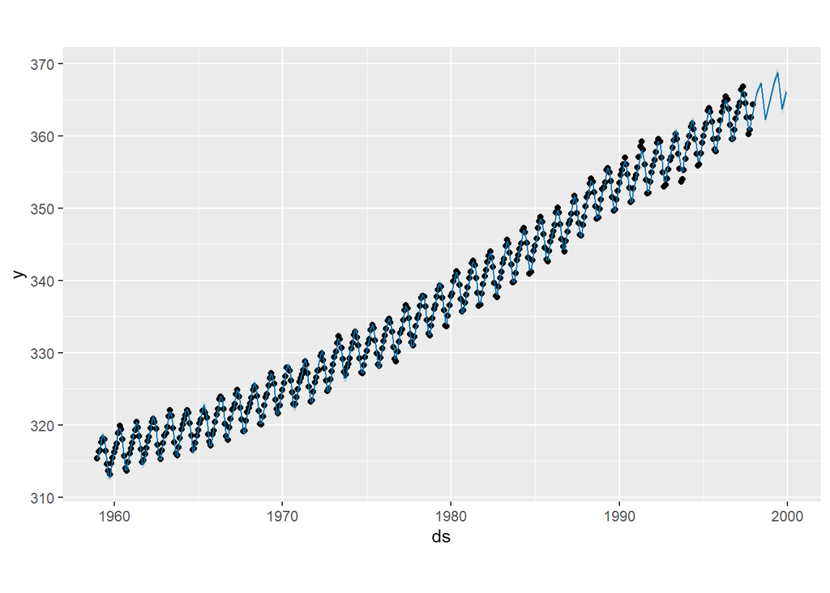

```r
# Generate future data frame for prediction
f = make_future_dataframe(m, periods=8, freq="quarter")

# Forecast
p = predict(m, f)

# Visualize the forecast
plot(m, p)
```

## Enhancing Our Analysis

Let’s examine patterns and seasonality to better comprehend. Decomposing the time series to see these components independently.

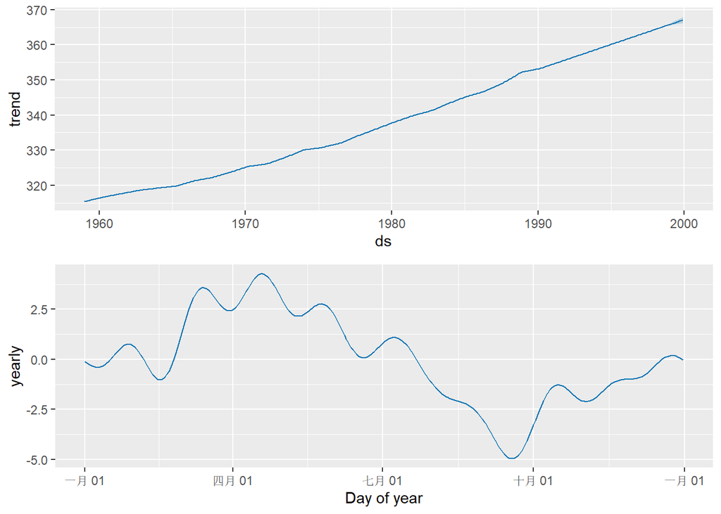

```r
prophet_plot_components(m, p)
```

```r
# Further Exploratory Data Analysis
# Plotting the raw data
plot(co2.df$ds, co2.df$y, type='l', main='Monthly CO2 Levels', xlab='Year', ylab='CO2 PPM', col='blue')

# Linear Trend Analysis
# A simple linear model to understand the growth of the series
linear_model <- lm(y ~ ds, data = co2.df)
summary(linear_model)
```

```
##
## Call:
## lm(formula = y ~ ds, data = co2.df)
##
## Residuals:
##     Min      1Q  Median      3Q     Max
## -6.0413 -1.9469  0.0004  1.9106  6.5161
##
## Coefficients:
##              Estimate Std. Error t value Pr(>|t|)
## (Intercept) 3.260e+02  1.514e-01  2153.2   <2e-16 ***
## ds          3.580e-03  2.944e-05   121.6   <2e-16 ***
## ---
## Signif. codes:  0 '***' 0.001 '**' 0.01 '*' 0.05 '.' 0.1 ' ' 1
##
## Residual standard error: 2.619 on 466 degrees of freedom
## Multiple R-squared:  0.9694, Adjusted R-squared:  0.9694
## F-statistic: 1.478e+04 on 1 and 466 DF,  p-value: < 2.2e-16
```

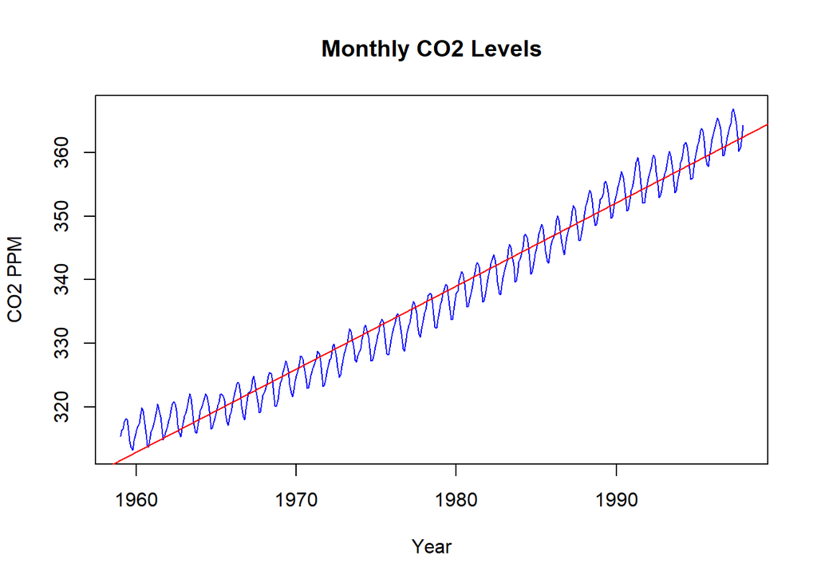

```r
# Add linear trend line to the plot
abline(linear_model, col="red")
```